# advertising

shinyarah

7/2/2021

## DEFINING THE QUESTION

an entrepreneur with an online cryptography course wishes to advertise it on her blog. The dataset provided contains data collected from target audiences from around the world. I am tasked with identifying which individuals are most likely to click on ads

## METRICS OF SUCCESS

I will need to find how different features are correlated. This means that they either have a positive or negative correlation coefficient. Success will be achieved once these features are identified

## CONTEXT

the dataset provided contains information on target audiences from across the globe. it has 1000rows and 10 columns

## loading the dataset

```r
advertising <- read.csv("http://bit.ly/IPAdvertisingData")
```

## Reading the dataset

```r
head(advertising)
```

```
##   Daily.Time.Spent.on.Site Age Area.Income Daily.Internet.Usage
## 1                    68.95  35    61833.90               256.09
## 2                    80.23  31    68441.85               193.77
## 3                    69.47  26    59785.94               236.50
## 4                    74.15  29    54806.18               245.89
## 5                    68.37  35    73889.99               225.58
## 6                    59.99  23    59761.56               226.74
##                           Ad.Topic.Line           City Male    Country
## 1    Cloned 5thgeneration orchestration    Wrightburgh    0    Tunisia
## 2    Monitored national standardization      West Jodi    1      Nauru
## 3      Organic bottom-line service-desk       Davidton    0 San Marino
## 4 Triple-buffered reciprocal time-frame West Terrifurt    1      Italy
## 5         Robust logistical utilization   South Manuel    0    Iceland
## 6       Sharable client-driven software      Jamieberg    1     Norway
##             Timestamp Clicked.on.Ad
## 1 2016-03-27 00:53:11             0
## 2 2016-04-04 01:39:02             0
## 3 2016-03-13 20:35:42             0
## 4 2016-01-10 02:31:19             0
## 5 2016-06-03 03:36:18             0
## 6 2016-05-19 14:30:17             0
```

```r
tail(advertising)
```

```
##      Daily.Time.Spent.on.Site Age Area.Income Daily.Internet.Usage
## 995                     43.70  28    63126.96               173.01
## 996                     72.97  30    71384.57               208.58
## 997                     51.30  45    67782.17               134.42
## 998                     51.63  51    42415.72               120.37
## 999                     55.55  19    41920.79               187.95
## 1000                    45.01  26    29875.80               178.35
##                             Ad.Topic.Line          City Male
## 995         Front-line bifurcated ability  Nicholasland    0
## 996         Fundamental modular algorithm     Duffystad    1
## 997       Grass-roots cohesive monitoring   New Darlene    1
## 998          Expanded intangible solution South Jessica    1
## 999  Proactive bandwidth-monitored policy   West Steven    0
## 1000      Virtual 5thgeneration emulation   Ronniemouth    0
##                     Country           Timestamp Clicked.on.Ad
## 995                 Mayotte 2016-04-04 03:57:48             1
## 996                 Lebanon 2016-02-11 21:49:00             1
## 997  Bosnia and Herzegovina 2016-04-22 02:07:01             1
## 998                Mongolia 2016-02-01 17:24:57             1
## 999               Guatemala 2016-03-24 02:35:54             0
## 1000                 Brazil 2016-06-03 21:43:21             1
```

```r
str(advertising)
```

```
## 'data.frame':    1000 obs. of  10 variables:
##  $ Daily.Time.Spent.on.Site: num  69 80.2 69.5 74.2 68.4 ...
##  $ Age                     : int  35 31 26 29 35 23 33 48 30 20 ...
##  $ Area.Income             : num  61834 68442 59786 54806 73890 ...
##  $ Daily.Internet.Usage    : num  256 194 236 246 226 ...
##  $ Ad.Topic.Line           : chr  "Cloned 5thgeneration orchestration" "Monitored national standardization" "Organic bottom-line service-desk" "Triple-buffered reciprocal time-frame" ...
##  $ City                    : chr  "Wrightburgh" "West Jodi" "Davidton" "West Terrifurt" ...
##  $ Male                    : int  0 1 0 1 0 1 0 1 1 1 ...
##  $ Country                 : chr  "Tunisia" "Nauru" "San Marino" "Italy" ...
##  $ Timestamp               : chr  "2016-03-27 00:53:11" "2016-04-04 01:39:02" "2016-03-13 20:35:42" "2016-01-10 02:31:19" ...
##  $ Clicked.on.Ad           : int  0 0 0 0 0 0 0 1 0 0 ...
```

```r
summary(advertising)
```

```
##  Daily.Time.Spent.on.Site      Age         Area.Income    Daily.Internet.Usage
##  Min.   :32.60            Min.   :19.00   Min.   :13996   Min.   :104.8
##  1st Qu.:51.36            1st Qu.:29.00   1st Qu.:47032   1st Qu.:138.8
##  Median :68.22            Median :35.00   Median :57012   Median :183.1
##  Mean   :65.00            Mean   :36.01   Mean   :55000   Mean   :180.0
##  3rd Qu.:78.55            3rd Qu.:42.00   3rd Qu.:65471   3rd Qu.:218.8
##  Max.   :91.43            Max.   :61.00   Max.   :79485   Max.   :270.0
##  Ad.Topic.Line          City                Male         Country
##  Length:1000        Length:1000        Min.   :0.000   Length:1000
##  Class :character   Class :character   1st Qu.:0.000   Class :character
##  Mode  :character   Mode  :character   Median :0.000   Mode  :character
##                                        Mean   :0.481
##                                        3rd Qu.:1.000
##                                        Max.   :1.000
##   Timestamp         Clicked.on.Ad
##  Length:1000        Min.   :0.0
##  Class :character   1st Qu.:0.0
##  Mode  :character   Median :0.5
##                     Mean   :0.5
##                     3rd Qu.:1.0
##                     Max.   :1.0
```

## finding null values

```r
is.na(advertising)
```

[output not shown]

[output cut: 1987 more lines]

## checking for duplicates and unique values

```r
duplicate_values <- advertising[duplicated(advertising),]
```

# explaratory data analysis

## univariate analysis

### measures of central tendency

#### column age

##### finding mean for the column age

```r
age_mean <- mean(advertising$Age)
age_mean
```

```
## [1] 36.009
```

##### finding the mode for age

```r
getmode <- function(v) {
   uniqv <- unique(v)
   uniqv[which.max(tabulate(match(v, uniqv)))]
}
age_mode <- getmode(advertising$age)
age_mode
```

[output not shown]

[output not shown]

```r
is.na(advertising$Age)
```

[output not shown]

[output cut: 69 more lines]

##### finding median for age

```r
age_median <- median(advertising$Age)
age_median
```

```
## [1] 35
```

#### column time_spent_on_site

##### mean

```r
dtsos_mean <- mean(advertising$Daily.Time.Spent.on.Site)
dtsos_mean
```

```
## [1] 65.0002
```

##### mode

```r
getmode <- function(v) {
   uniqv <- unique(v)
   uniqv[which.max(tabulate(match(v, uniqv)))]
}
dtsos_mode <- getmode(advertising$Daily.Time.Spent.on.Site)
dtsos_mode
```

```
## [1] 62.26
```

##### median

```r
dtsos_median <- median(advertising$Daily.Time.Spent.on.Site)
dtsos_median
```

```
## [1] 68.215
```

#### column area_income

##### mean

```r
ai_mean <- mean(advertising$Area.Income)
ai_mean
```

```
## [1] 55000
```

##### mode

```r
getmode <- function(v) {
   uniqv <- unique(v)
   uniqv[which.max(tabulate(match(v, uniqv)))]
}
ai_mode <- getmode(advertising$Area.Income)
ai_mode
```

```
## [1] 61833.9
```

##### median

```r
ai_median <- median(advertising$Area.Income)
ai_median
```

```
## [1] 57012.3
```

#### column daily internet usage

##### mean

```r
diu_mean <- mean(advertising$Daily.Internet.Usage)
diu_mean
```

```
## [1] 180.0001
```

##### mode

```r
getmode <- function(v) {
   uniqv <- unique(v)
   uniqv[which.max(tabulate(match(v, uniqv)))]
}
diu_mode <- getmode(advertising$Daily.Internet.Usage)
diu_mode
```

```
## [1] 167.22
```

##### median

```r
diu_median <- median(advertising$Daily.Internet.Usage)
diu_median
```

```
## [1] 183.13
```

#### categorical variables

```r
ad_topic <- advertising$Ad.Topic.Line
city <- advertising$City
gender <- advertising$Male
country <- advertising$Country
clicked <- advertising$Clicked.on.Ad
ai <- advertising$Area.Income
```

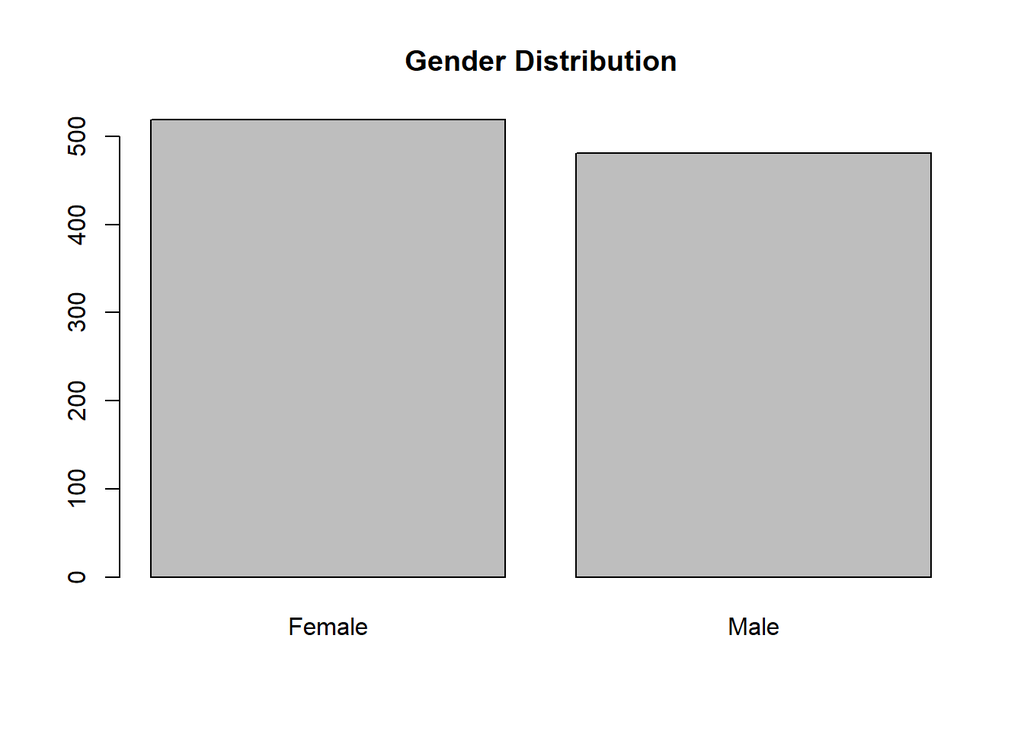

```r
Gender_dist <- table(gender)
label <- c("Female","Male")
barplot(Gender_dist,names.arg = label,main = "Gender Distribution")
```

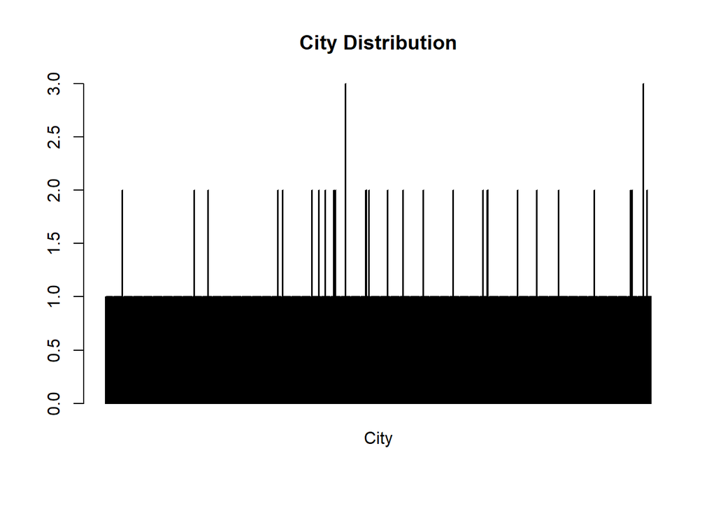

```r
city_dist <- table(city)
label <- c("City")
barplot(city_dist,names.arg = label,main = "City Distribution")
```

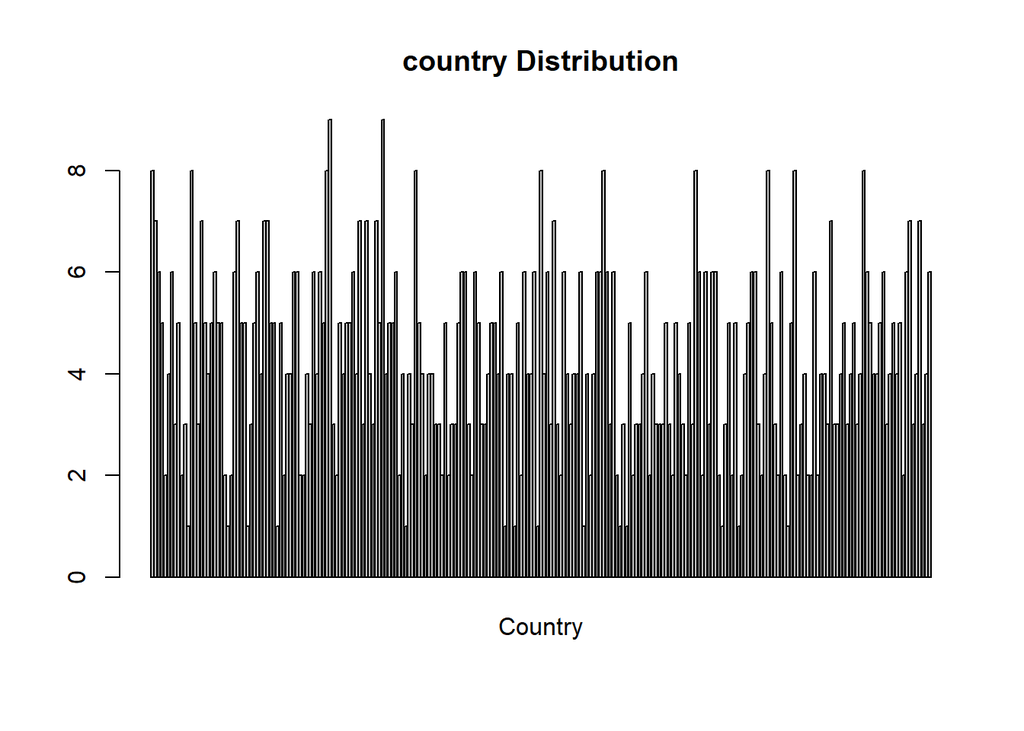

```r
country_dist <- table(country)
label <- c("Country")
barplot(country_dist,names.arg = label,main = "country Distribution")
```

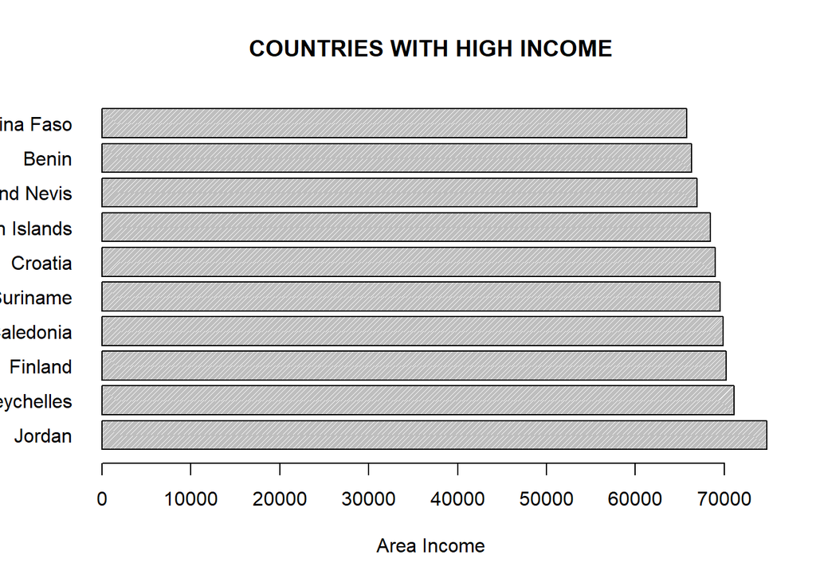

```r
# top 10 countries with high average income
avg.country = aggregate(ai, by = list(country), FUN = mean)
cou.top10 <- head(avg.country[order(avg.country$x,decreasing = TRUE), ],10)
barplot(cou.top10$x,main = "COUNTRIES WITH HIGH INCOME",
        xlab = "Area Income",
        density = 80,
        las=1,
        names=cou.top10$Group.1,
        horiz = TRUE)
```

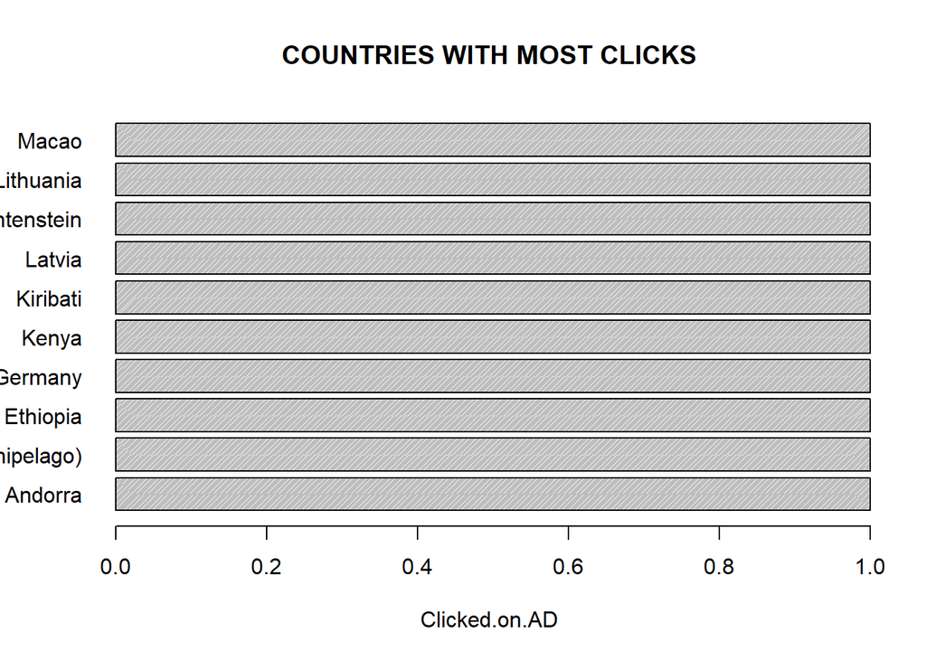

```r
avg.country = aggregate(clicked, by = list(country), FUN = mean)
cou.top10 <- head(avg.country[order(avg.country$x,decreasing = TRUE), ],10)
barplot(cou.top10$x,main = "COUNTRIES WITH MOST CLICKS",
        xlab = "Clicked.on.AD",
        density = 80,
        las=1,
        names=cou.top10$Group.1,
        horiz = TRUE)
```

### measures of dispersion

#### column age

##### variance

```r
age_variance <- var(advertising$Age)
age_variance
```

```
## [1] 77.18611
```

##### standard deviation

```r
age_sd <- sd(advertising$Age)
age_sd
```

```
## [1] 8.785562
```

##### range

```r
age_range <- range(advertising$Age)
age_range
```

```
## [1] 19 61
```

##### quantile

```r
age_qt <- quantile(advertising$Age)
age_qt
```

```
##   0%  25%  50%  75% 100%
##   19   29   35   42   61
```

##### skew

```r
library(moments)
age_skew <- skewness(advertising$Age)
age_skew
```

```
## [1] 0.4784227
```

##### kurtosis

```r
#install.packages("e1071")
age_kurt <- kurtosis(advertising$Age)
age_kurt
```

```
## [1] 2.595482
```

#### column time_spent_on_site

##### variance

```r
dstot_var <- var(advertising$Daily.Time.Spent.on.Site)
dstot_var
```

```
## [1] 251.3371
```

##### standard deviation

```r
dstot_sd <- sd(advertising$Daily.Time.Spent.on.Site)
dstot_sd
```

```
## [1] 15.85361
```

##### range

```r
dstot_range <- range(advertising$Daily.Time.Spent.on.Site)
dstot_range
```

```
## [1] 32.60 91.43
```

##### quantile

```r
dstot_qt <- quantile(advertising$Daily.Time.Spent.on.Site)
dstot_qt
```

```
##      0%     25%     50%     75%    100%
## 32.6000 51.3600 68.2150 78.5475 91.4300
```

##### skew

```r
#install.packages("moments")
library(moments)
dstot_skew <- skewness(advertising$Daily.Time.Spent.on.Site)
dstot_skew
```

```
## [1] -0.3712026
```

##### kurtosis

```r
#install.packages("e1071")
dstot_kurt <- kurtosis(advertising$Daily.Time.Spent.on.Site)
dstot_kurt
```

```
## [1] 1.903942
```

#### column area income

##### variance

```r
ai_var <- var(advertising$Area.Income)
ai_var
```

```
## [1] 179952406
```

##### standard deviation

```r
ai_sd <- sd(advertising$Area.Income)
ai_sd
```

```
## [1] 13414.63
```

##### range

```r
ai_range <- range(advertising$Area.Income)
ai_range
```

```
## [1] 13996.5 79484.8
```

##### quantile

```r
ai_qt <- quantile(advertising$Area.Income)
ai_qt
```

```
##       0%      25%      50%      75%     100%
## 13996.50 47031.80 57012.30 65470.64 79484.80
```

##### skew

```r
#install.packages("moments")
library(moments)
ai_skew <- skewness(advertising$Area.Income)
ai_skew
```

```
## [1] -0.6493967
```

##### kurtosis

```r
#install.packages("e1071")
ai_kurt <- kurtosis(advertising$Area.Income)
ai_kurt
```

```
## [1] 2.894694
```

#### column daily internet usage

##### variance

```r
diu_var <- var(advertising$Daily.Internet.Usage)
diu_var
```

```
## [1] 1927.415
```

##### standard deviation

```r
diu_sd <- sd(advertising$Daily.Internet.Usage)
diu_sd
```

```
## [1] 43.90234
```

##### range

```r
diu_range <- range(advertising$Daily.Internet.Usage)
diu_range
```

```
## [1] 104.78 269.96
```

##### quantile

```r
diu_qt <- quantile(advertising$Daily.Internet.Usage)
diu_qt
```

```
##       0%      25%      50%      75%     100%
## 104.7800 138.8300 183.1300 218.7925 269.9600
```

##### skew

```r
#install.packages("moments")
library(moments)
diu_skew <- skewness(advertising$Daily.Internet.Usage)
diu_skew
```

```
## [1] -0.03348703
```

##### kurtosis

```r
#install.packages("e1071")
diu_kurt <- kurtosis(advertising$Daily.Internet.Usage)
diu_kurt
```

```
## [1] 1.727701
```